# Coin Problem

Simon Thornewill von Essen

12/19/2019

# Implementation of Coin Problem from Lectures

## Describing the problem

In the lecture we are given a situation where we have both a loaded and a fair coin. If we take one out of the bag and flip it, we will see either heads or tails.

What we want to estimate is whether the coin is fair or loaded given that we saw two heads.

We know the following

| coin type | probability of heads | probability of drawing coin from bag |
| --- | --- | --- |
| fair | 0.5 | 0.4 |
| loaded | 0.7 | 0.6 |

Then, we need to calculate an alpha value, for this we also need to have a proposal candidate.

We will have a deterministic proposal which means that we will suggest the opposite choice to whatever we last drew.

Since our proposal is deterministic, our q-function will always be 1. This means that we calculate alpha like so:

$$\alpha = \frac{f(x=2 | \theta^*)}{f(x=2 | \theta_i)}$$

Interestingly enough, since q is deterministic, so is alpha. It only depends on What we propose the new theta to be.

| proposed theta | $\alpha$ | action |
| --- | --- | --- |
| fair | 1.574 | always accept |
| loaded | 0.635 | accept with propbability 0.635 |

This means that we have generated the markov chain that we expected to. We can then check this markov chain’s stationary distribution.

## Coding the solution

```r
fx <- function(X, theta){
  if(theta == 0){
    return((0.4)*(.5^5))
  }else{
    return((0.6)*(.7^X)*(.3^(5-X)))
  }
}

calculate_alpha <- function(theta_old, theta_new){
  return((fx(X=2, theta=theta_new))/(fx(X=2, theta=theta_old)))
}
```

We can test that these functions are working as intended

```r
for(i in 0:1){
  new <- i
  old <- 1 - new

  print(calculate_alpha(theta_new = new, theta_old = old))
}
```

```
## [1] 1.574704
## [1] 0.63504
```

We can see above that when the coin is fair, we get an alpha of `1.574704`, and an alpha of `0.63504` when loaded which is the same as what prof. Herbert Lee calculates.

Next, we need to do the sampling…

```r
n_iter <- 100000
thetas <- numeric(n_iter)

# Init on the first step
theta_star <- rbern(1, 0.7)
thetas[1] <- theta_star
debug <- FALSE

for(i in 2:n_iter){

  # Propose alternate
  if (thetas[i-1]==1){
    theta_star <- 0
  } else {
    theta_star <- 1
  }

  # Calculate alpha
  alpha <- calculate_alpha(theta_old = thetas[i-1], theta_new = theta_star)
  #print(alpha)

  # Do evaluation
  if(alpha>1){
    thetas[i] <- theta_star
    if(debug){
      print("Alpha larger than 1, accepting and continuing")
    }
  }else if((alpha > 0) & (rbern(1, alpha))){
    thetas[i] <- theta_star
    if(debug){
      print("Alpha accepted by probability and continuing")
    }
  }else{
    thetas[i] <- thetas[i-1]
    if(debug){
      print("Test failed, setting last theta and continuing")
    }
  }
}

head(thetas, 10)
```

[output not shown]

Now that we have completed our sampling, we can compare the value we estimated with the true value:

```r
print(mean(thetas))
```

```
## [1] 0.38693
```

```r
print(0.388)
```

```
## [1] 0.388
```

We can see that we are quite close to the true number.

We can even consider bootstrapping from our large vector to create a histogram, this will show us the credible values for theta.

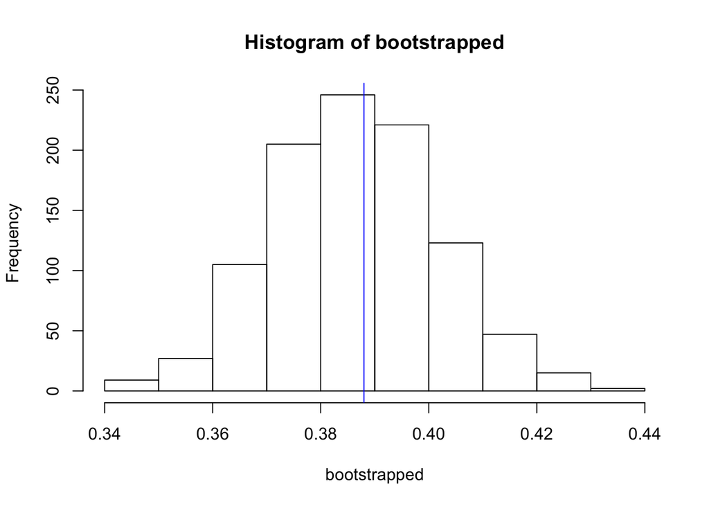

```r
n_iter <- 1000
bootstrapped <- numeric(n_iter)

for(i in 1:n_iter){
  s <- sample(thetas, n_iter)
  bootstrapped[i] <- mean(s)
}

hist(bootstrapped)
abline(v=0.388, col='blue')
```

We can see above a histogram for the credible values of theta as well as the true value with blue. We could even start calculating other statistics such as highest density values and things like that.